# Effects of Gender on distance and duration of bike usage

## Investigation Overview

In this investigation, I will be looking at how gender affects duration of use and distance covered during the usage of the bikes.

## Dataset Overview

The data consisted of data on 183,412 bikes. The features incuded the duration sec, start time, end time, start station id, start station name, start station latitude, start station longitude, end station id, end station name, end station latitude, end station longitude, bike id, user type, member birth year, member gender, bike share for all trip. One row was removed from the data for inconsistent information.

## Distribution of Gender

The gender categories in the bikes dataset are; Male, Female and Other. Plotted using seaborn and maintaing the default color variations. Men are by a large margin of over 80,000 more then the women and the "other " gender is the least of the 3.

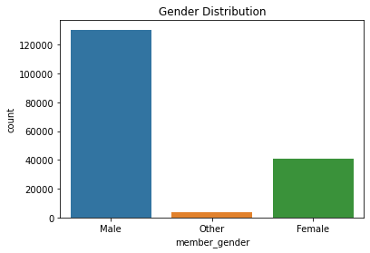

# Distribution of Distance

Distance was derived using Haversine. It was done with data provided in the longitude and latitude columns provided in the dataset. The distance was calculated in KM and plotted on a small binsize in order to cover for the large variations in the dataset. It shows that most users covered between 1-2KMS with very few users covering more than 5KM

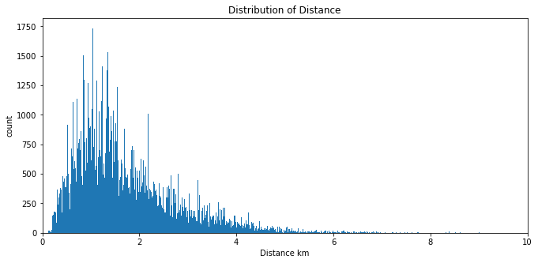

## Distribution of Duration

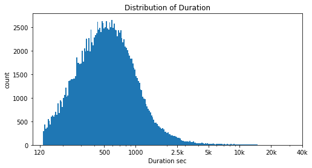

## Distance and Duration by Gender

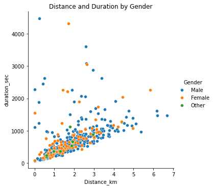